# DFOIL replication

```r
                    dfo(table)[[1]], dil(table)[[1]], dfi(table)[[1]], dol(table)[[1]],
                  DELTA1(table)[[1]], DELTA2(table)[[1]], DELTA3(table)[[1]], DELTA4(table)[[1]],
                    DELTA5(table)[[1]], DELTA6(table)[[1]], DELTA7(table)[[1]], DELTA8(table)[[1]])
pvalue <- c(pvalue, DFO(table)[[2]], DIL(table)[[2]], DFI(table)[[2]], DOL(table)[[2]],
                      dfo(table)[[2]], dil(table)[[2]], dfi(table)[[2]], dol(table)[[2]],
                      DELTA1(table)[[2]], DELTA2(table)[[2]], DELTA3(table)[[2]], DELTA4(table)[[2]],
                      DELTA5(table)[[2]], DELTA6(table)[[2]], DELTA7(table)[[2]], DELTA8(table)[[2]])
sign <- c(sign, DFO(table)[[3]], DIL(table)[[3]], DFI(table)[[3]], DOL(table)[[3]],
                  dfo(table)[[3]], dil(table)[[3]], dfi(table)[[3]], dol(table)[[3]],
                DELTA1(table)[[3]], DELTA2(table)[[3]], DELTA3(table)[[3]], DELTA4(table)[[3]],
                  DELTA5(table)[[3]], DELTA6(table)[[3]], DELTA7(table)[[3]], DELTA8(table)[[3]])
# P3 -> P12
table <- tables[[10]]
event <- c(event, rep("P3 -> P12", 16))
statistic <- c(statistic, "DFO", "DIL", "DFI", "DOL",
                            "dfo", "dil", "dfi", "dol",
                            "DELTA1", "DELTA2", "DELTA3", "DELTA4",
                            "DELTA5", "DELTA6", "DELTA7", "DELTA8")
value <- c(value, DFO(table)[[1]], DIL(table)[[1]], DFI(table)[[1]], DOL(table)[[1]],
                    dfo(table)[[1]], dil(table)[[1]], dfi(table)[[1]], dol(table)[[1]],
                  DELTA1(table)[[1]], DELTA2(table)[[1]], DELTA3(table)[[1]], DELTA4(table)[[1]],
                    DELTA5(table)[[1]], DELTA6(table)[[1]], DELTA7(table)[[1]], DELTA8(table)[[1]])
pvalue <- c(pvalue, DFO(table)[[2]], DIL(table)[[2]], DFI(table)[[2]], DOL(table)[[2]],
                      dfo(table)[[2]], dil(table)[[2]], dfi(table)[[2]], dol(table)[[2]],
                      DELTA1(table)[[2]], DELTA2(table)[[2]], DELTA3(table)[[2]], DELTA4(table)[[2]],
                      DELTA5(table)[[2]], DELTA6(table)[[2]], DELTA7(table)[[2]], DELTA8(table)[[2]])
sign <- c(sign, DFO(table)[[3]], DIL(table)[[3]], DFI(table)[[3]], DOL(table)[[3]],
                  dfo(table)[[3]], dil(table)[[3]], dfi(table)[[3]], dol(table)[[3]],
                DELTA1(table)[[3]], DELTA2(table)[[3]], DELTA3(table)[[3]], DELTA4(table)[[3]],
                  DELTA5(table)[[3]], DELTA6(table)[[3]], DELTA7(table)[[3]], DELTA8(table)[[3]])
# P12 -> P4
table <- tables[[11]]
event <- c(event, rep("P12 -> P4", 16))
statistic <- c(statistic, "DFO", "DIL", "DFI", "DOL",
                            "dfo", "dil", "dfi", "dol",
                            "DELTA1", "DELTA2", "DELTA3", "DELTA4",
                            "DELTA5", "DELTA6", "DELTA7", "DELTA8")
value <- c(value, DFO(table)[[1]], DIL(table)[[1]], DFI(table)[[1]], DOL(table)[[1]],
                    dfo(table)[[1]], dil(table)[[1]], dfi(table)[[1]], dol(table)[[1]],
                  DELTA1(table)[[1]], DELTA2(table)[[1]], DELTA3(table)[[1]], DELTA4(table)[[1]],
                    DELTA5(table)[[1]], DELTA6(table)[[1]], DELTA7(table)[[1]], DELTA8(table)[[1]])
pvalue <- c(pvalue, DFO(table)[[2]], DIL(table)[[2]], DFI(table)[[2]], DOL(table)[[2]],
                      dfo(table)[[2]], dil(table)[[2]], dfi(table)[[2]], dol(table)[[2]],
                      DELTA1(table)[[2]], DELTA2(table)[[2]], DELTA3(table)[[2]], DELTA4(table)[[2]],
                      DELTA5(table)[[2]], DELTA6(table)[[2]], DELTA7(table)[[2]], DELTA8(table)[[2]])
sign <- c(sign, DFO(table)[[3]], DIL(table)[[3]], DFI(table)[[3]], DOL(table)[[3]],
                  dfo(table)[[3]], dil(table)[[3]], dfi(table)[[3]], dol(table)[[3]],
                DELTA1(table)[[3]], DELTA2(table)[[3]], DELTA3(table)[[3]], DELTA4(table)[[3]],
                  DELTA5(table)[[3]], DELTA6(table)[[3]], DELTA7(table)[[3]], DELTA8(table)[[3]])
# P4 -> P12
table <- tables[[12]]
event <- c(event, rep("P4 -> P12", 16))
statistic <- c(statistic, "DFO", "DIL", "DFI", "DOL",
                            "dfo", "dil", "dfi", "dol",
                            "DELTA1", "DELTA2", "DELTA3", "DELTA4",
                            "DELTA5", "DELTA6", "DELTA7", "DELTA8")
value <- c(value, DFO(table)[[1]], DIL(table)[[1]], DFI(table)[[1]], DOL(table)[[1]],
                    dfo(table)[[1]], dil(table)[[1]], dfi(table)[[1]], dol(table)[[1]],
                  DELTA1(table)[[1]], DELTA2(table)[[1]], DELTA3(table)[[1]], DELTA4(table)[[1]],
                    DELTA5(table)[[1]], DELTA6(table)[[1]], DELTA7(table)[[1]], DELTA8(table)[[1]])
pvalue <- c(pvalue, DFO(table)[[2]], DIL(table)[[2]], DFI(table)[[2]], DOL(table)[[2]],
                      dfo(table)[[2]], dil(table)[[2]], dfi(table)[[2]], dol(table)[[2]],
                      DELTA1(table)[[2]], DELTA2(table)[[2]], DELTA3(table)[[2]], DELTA4(table)[[2]],
                      DELTA5(table)[[2]], DELTA6(table)[[2]], DELTA7(table)[[2]], DELTA8(table)[[2]])
sign <- c(sign, DFO(table)[[3]], DIL(table)[[3]], DFI(table)[[3]], DOL(table)[[3]],
                  dfo(table)[[3]], dil(table)[[3]], dfi(table)[[3]], dol(table)[[3]],
                DELTA1(table)[[3]], DELTA2(table)[[3]], DELTA3(table)[[3]], DELTA4(table)[[3]],
                  DELTA5(table)[[3]], DELTA6(table)[[3]], DELTA7(table)[[3]], DELTA8(table)[[3]])
# P34 -> P1
table <- tables[[13]]
event <- c(event, rep("P34 -> P1", 16))
statistic <- c(statistic, "DFO", "DIL", "DFI", "DOL",
                            "dfo", "dil", "dfi", "dol",
                            "DELTA1", "DELTA2", "DELTA3", "DELTA4",
                            "DELTA5", "DELTA6", "DELTA7", "DELTA8")
value <- c(value, DFO(table)[[1]], DIL(table)[[1]], DFI(table)[[1]], DOL(table)[[1]],
                    dfo(table)[[1]], dil(table)[[1]], dfi(table)[[1]], dol(table)[[1]],
                  DELTA1(table)[[1]], DELTA2(table)[[1]], DELTA3(table)[[1]], DELTA4(table)[[1]],
                    DELTA5(table)[[1]], DELTA6(table)[[1]], DELTA7(table)[[1]], DELTA8(table)[[1]])
pvalue <- c(pvalue, DFO(table)[[2]], DIL(table)[[2]], DFI(table)[[2]], DOL(table)[[2]],
                      dfo(table)[[2]], dil(table)[[2]], dfi(table)[[2]], dol(table)[[2]],
                      DELTA1(table)[[2]], DELTA2(table)[[2]], DELTA3(table)[[2]], DELTA4(table)[[2]],
                      DELTA5(table)[[2]], DELTA6(table)[[2]], DELTA7(table)[[2]], DELTA8(table)[[2]])
sign <- c(sign, DFO(table)[[3]], DIL(table)[[3]], DFI(table)[[3]], DOL(table)[[3]],
                  dfo(table)[[3]], dil(table)[[3]], dfi(table)[[3]], dol(table)[[3]],
                DELTA1(table)[[3]], DELTA2(table)[[3]], DELTA3(table)[[3]], DELTA4(table)[[3]],
                  DELTA5(table)[[3]], DELTA6(table)[[3]], DELTA7(table)[[3]], DELTA8(table)[[3]])
# P1 -> P34
table <- tables[[14]]
event <- c(event, rep("P1 -> P34", 16))
statistic <- c(statistic, "DFO", "DIL", "DFI", "DOL",
                            "dfo", "dil", "dfi", "dol",
                            "DELTA1", "DELTA2", "DELTA3", "DELTA4",
                            "DELTA5", "DELTA6", "DELTA7", "DELTA8")
value <- c(value, DFO(table)[[1]], DIL(table)[[1]], DFI(table)[[1]], DOL(table)[[1]],
                    dfo(table)[[1]], dil(table)[[1]], dfi(table)[[1]], dol(table)[[1]],
                  DELTA1(table)[[1]], DELTA2(table)[[1]], DELTA3(table)[[1]], DELTA4(table)[[1]],
                    DELTA5(table)[[1]], DELTA6(table)[[1]], DELTA7(table)[[1]], DELTA8(table)[[1]])
pvalue <- c(pvalue, DFO(table)[[2]], DIL(table)[[2]], DFI(table)[[2]], DOL(table)[[2]],
                      dfo(table)[[2]], dil(table)[[2]], dfi(table)[[2]], dol(table)[[2]],
                      DELTA1(table)[[2]], DELTA2(table)[[2]], DELTA3(table)[[2]], DELTA4(table)[[2]],
                      DELTA5(table)[[2]], DELTA6(table)[[2]], DELTA7(table)[[2]], DELTA8(table)[[2]])
sign <- c(sign, DFO(table)[[3]], DIL(table)[[3]], DFI(table)[[3]], DOL(table)[[3]],
                  dfo(table)[[3]], dil(table)[[3]], dfi(table)[[3]], dol(table)[[3]],
                DELTA1(table)[[3]], DELTA2(table)[[3]], DELTA3(table)[[3]], DELTA4(table)[[3]],
                  DELTA5(table)[[3]], DELTA6(table)[[3]], DELTA7(table)[[3]], DELTA8(table)[[3]])
# P34 -> P2
table <- tables[[15]]
event <- c(event, rep("P34 -> P2", 16))
statistic <- c(statistic, "DFO", "DIL", "DFI", "DOL",
                            "dfo", "dil", "dfi", "dol",
                            "DELTA1", "DELTA2", "DELTA3", "DELTA4",
                            "DELTA5", "DELTA6", "DELTA7", "DELTA8")
value <- c(value, DFO(table)[[1]], DIL(table)[[1]], DFI(table)[[1]], DOL(table)[[1]],
                    dfo(table)[[1]], dil(table)[[1]], dfi(table)[[1]], dol(table)[[1]],
                  DELTA1(table)[[1]], DELTA2(table)[[1]], DELTA3(table)[[1]], DELTA4(table)[[1]],
                    DELTA5(table)[[1]], DELTA6(table)[[1]], DELTA7(table)[[1]], DELTA8(table)[[1]])
pvalue <- c(pvalue, DFO(table)[[2]], DIL(table)[[2]], DFI(table)[[2]], DOL(table)[[2]],
                      dfo(table)[[2]], dil(table)[[2]], dfi(table)[[2]], dol(table)[[2]],
                      DELTA1(table)[[2]], DELTA2(table)[[2]], DELTA3(table)[[2]], DELTA4(table)[[2]],
                      DELTA5(table)[[2]], DELTA6(table)[[2]], DELTA7(table)[[2]], DELTA8(table)[[2]])
sign <- c(sign, DFO(table)[[3]], DIL(table)[[3]], DFI(table)[[3]], DOL(table)[[3]],
                  dfo(table)[[3]], dil(table)[[3]], dfi(table)[[3]], dol(table)[[3]],
                DELTA1(table)[[3]], DELTA2(table)[[3]], DELTA3(table)[[3]], DELTA4(table)[[3]],
                  DELTA5(table)[[3]], DELTA6(table)[[3]], DELTA7(table)[[3]], DELTA8(table)[[3]])
# P2 -> P34
table <- tables[[16]]
event <- c(event, rep("P2 -> P34", 16))
statistic <- c(statistic, "DFO", "DIL", "DFI", "DOL",
                            "dfo", "dil", "dfi", "dol",
                            "DELTA1", "DELTA2", "DELTA3", "DELTA4",
                            "DELTA5", "DELTA6", "DELTA7", "DELTA8")
value <- c(value, DFO(table)[[1]], DIL(table)[[1]], DFI(table)[[1]], DOL(table)[[1]],
                    dfo(table)[[1]], dil(table)[[1]], dfi(table)[[1]], dol(table)[[1]],
                  DELTA1(table)[[1]], DELTA2(table)[[1]], DELTA3(table)[[1]], DELTA4(table)[[1]],
                    DELTA5(table)[[1]], DELTA6(table)[[1]], DELTA7(table)[[1]], DELTA8(table)[[1]])
pvalue <- c(pvalue, DFO(table)[[2]], DIL(table)[[2]], DFI(table)[[2]], DOL(table)[[2]],
                      dfo(table)[[2]], dil(table)[[2]], dfi(table)[[2]], dol(table)[[2]],
                      DELTA1(table)[[2]], DELTA2(table)[[2]], DELTA3(table)[[2]], DELTA4(table)[[2]],
                      DELTA5(table)[[2]], DELTA6(table)[[2]], DELTA7(table)[[2]], DELTA8(table)[[2]])
sign <- c(sign, DFO(table)[[3]], DIL(table)[[3]], DFI(table)[[3]], DOL(table)[[3]],
                  dfo(table)[[3]], dil(table)[[3]], dfi(table)[[3]], dol(table)[[3]],
                DELTA1(table)[[3]], DELTA2(table)[[3]], DELTA3(table)[[3]], DELTA4(table)[[3]],
                  DELTA5(table)[[3]], DELTA6(table)[[3]], DELTA7(table)[[3]], DELTA8(table)[[3]])
# P1 -> P5
table <- tables[[17]]
event <- c(event, rep("P1 -> P5", 16))
statistic <- c(statistic, "DFO", "DIL", "DFI", "DOL",
                            "dfo", "dil", "dfi", "dol",
                            "DELTA1", "DELTA2", "DELTA3", "DELTA4",
                            "DELTA5", "DELTA6", "DELTA7", "DELTA8")
value <- c(value, DFO(table)[[1]], DIL(table)[[1]], DFI(table)[[1]], DOL(table)[[1]],
                    dfo(table)[[1]], dil(table)[[1]], dfi(table)[[1]], dol(table)[[1]],
                  DELTA1(table)[[1]], DELTA2(table)[[1]], DELTA3(table)[[1]], DELTA4(table)[[1]],
                    DELTA5(table)[[1]], DELTA6(table)[[1]], DELTA7(table)[[1]], DELTA8(table)[[1]])
pvalue <- c(pvalue, DFO(table)[[2]], DIL(table)[[2]], DFI(table)[[2]], DOL(table)[[2]],
                      dfo(table)[[2]], dil(table)[[2]], dfi(table)[[2]], dol(table)[[2]],
                      DELTA1(table)[[2]], DELTA2(table)[[2]], DELTA3(table)[[2]], DELTA4(table)[[2]],
```

```r
                      DELTA5(table)[[2]], DELTA6(table)[[2]], DELTA7(table)[[2]], DELTA8(table)[[2]])
sign <- c(sign, DFO(table)[[3]], DIL(table)[[3]], DFI(table)[[3]], DOL(table)[[3]],
                  dfo(table)[[3]], dil(table)[[3]], dfi(table)[[3]], dol(table)[[3]],
                DELTA1(table)[[3]], DELTA2(table)[[3]], DELTA3(table)[[3]], DELTA4(table)[[3]],
                  DELTA5(table)[[3]], DELTA6(table)[[3]], DELTA7(table)[[3]], DELTA8(table)[[3]])
# P5 -> P1
table <- tables[[18]]
event <- c(event, rep("P5 -> P1", 16))
statistic <- c(statistic, "DFO", "DIL", "DFI", "DOL",
                            "dfo", "dil", "dfi", "dol",
                            "DELTA1", "DELTA2", "DELTA3", "DELTA4",
                            "DELTA5", "DELTA6", "DELTA7", "DELTA8")
value <- c(value, DFO(table)[[1]], DIL(table)[[1]], DFI(table)[[1]], DOL(table)[[1]],
                    dfo(table)[[1]], dil(table)[[1]], dfi(table)[[1]], dol(table)[[1]],
                  DELTA1(table)[[1]], DELTA2(table)[[1]], DELTA3(table)[[1]], DELTA4(table)[[1]],
                    DELTA5(table)[[1]], DELTA6(table)[[1]], DELTA7(table)[[1]], DELTA8(table)[[1]])
pvalue <- c(pvalue, DFO(table)[[2]], DIL(table)[[2]], DFI(table)[[2]], DOL(table)[[2]],
                      dfo(table)[[2]], dil(table)[[2]], dfi(table)[[2]], dol(table)[[2]],
                      DELTA1(table)[[2]], DELTA2(table)[[2]], DELTA3(table)[[2]], DELTA4(table)[[2]],
                      DELTA5(table)[[2]], DELTA6(table)[[2]], DELTA7(table)[[2]], DELTA8(table)[[2]])
sign <- c(sign, DFO(table)[[3]], DIL(table)[[3]], DFI(table)[[3]], DOL(table)[[3]],
                  dfo(table)[[3]], dil(table)[[3]], dfi(table)[[3]], dol(table)[[3]],
                DELTA1(table)[[3]], DELTA2(table)[[3]], DELTA3(table)[[3]], DELTA4(table)[[3]],
                  DELTA5(table)[[3]], DELTA6(table)[[3]], DELTA7(table)[[3]], DELTA8(table)[[3]])
# P2 -> P5
table <- tables[[19]]
event <- c(event, rep("P2 -> P5", 16))
statistic <- c(statistic, "DFO", "DIL", "DFI", "DOL",
                            "dfo", "dil", "dfi", "dol",
                            "DELTA1", "DELTA2", "DELTA3", "DELTA4",
                            "DELTA5", "DELTA6", "DELTA7", "DELTA8")
value <- c(value, DFO(table)[[1]], DIL(table)[[1]], DFI(table)[[1]], DOL(table)[[1]],
                    dfo(table)[[1]], dil(table)[[1]], dfi(table)[[1]], dol(table)[[1]],
                  DELTA1(table)[[1]], DELTA2(table)[[1]], DELTA3(table)[[1]], DELTA4(table)[[1]],
                    DELTA5(table)[[1]], DELTA6(table)[[1]], DELTA7(table)[[1]], DELTA8(table)[[1]])
pvalue <- c(pvalue, DFO(table)[[2]], DIL(table)[[2]], DFI(table)[[2]], DOL(table)[[2]],
                      dfo(table)[[2]], dil(table)[[2]], dfi(table)[[2]], dol(table)[[2]],
                      DELTA1(table)[[2]], DELTA2(table)[[2]], DELTA3(table)[[2]], DELTA4(table)[[2]],
                      DELTA5(table)[[2]], DELTA6(table)[[2]], DELTA7(table)[[2]], DELTA8(table)[[2]])
sign <- c(sign, DFO(table)[[3]], DIL(table)[[3]], DFI(table)[[3]], DOL(table)[[3]],
                  dfo(table)[[3]], dil(table)[[3]], dfi(table)[[3]], dol(table)[[3]],
                DELTA1(table)[[3]], DELTA2(table)[[3]], DELTA3(table)[[3]], DELTA4(table)[[3]],
                  DELTA5(table)[[3]], DELTA6(table)[[3]], DELTA7(table)[[3]], DELTA8(table)[[3]])
# P5 -> P2
table <- tables[[20]]
event <- c(event, rep("P5 -> P2", 16))
statistic <- c(statistic, "DFO", "DIL", "DFI", "DOL",
                            "dfo", "dil", "dfi", "dol",
                            "DELTA1", "DELTA2", "DELTA3", "DELTA4",
                            "DELTA5", "DELTA6", "DELTA7", "DELTA8")
value <- c(value, DFO(table)[[1]], DIL(table)[[1]], DFI(table)[[1]], DOL(table)[[1]],
                    dfo(table)[[1]], dil(table)[[1]], dfi(table)[[1]], dol(table)[[1]],
                  DELTA1(table)[[1]], DELTA2(table)[[1]], DELTA3(table)[[1]], DELTA4(table)[[1]],
                    DELTA5(table)[[1]], DELTA6(table)[[1]], DELTA7(table)[[1]], DELTA8(table)[[1]])
pvalue <- c(pvalue, DFO(table)[[2]], DIL(table)[[2]], DFI(table)[[2]], DOL(table)[[2]],
                      dfo(table)[[2]], dil(table)[[2]], dfi(table)[[2]], dol(table)[[2]],
                      DELTA1(table)[[2]], DELTA2(table)[[2]], DELTA3(table)[[2]], DELTA4(table)[[2]],
                      DELTA5(table)[[2]], DELTA6(table)[[2]], DELTA7(table)[[2]], DELTA8(table)[[2]])
sign <- c(sign, DFO(table)[[3]], DIL(table)[[3]], DFI(table)[[3]], DOL(table)[[3]],
                  dfo(table)[[3]], dil(table)[[3]], dfi(table)[[3]], dol(table)[[3]],
                DELTA1(table)[[3]], DELTA2(table)[[3]], DELTA3(table)[[3]], DELTA4(table)[[3]],
                  DELTA5(table)[[3]], DELTA6(table)[[3]], DELTA7(table)[[3]], DELTA8(table)[[3]])
# P3 -> P5
table <- tables[[21]]
event <- c(event, rep("P3 -> P5", 16))
statistic <- c(statistic, "DFO", "DIL", "DFI", "DOL",
                            "dfo", "dil", "dfi", "dol",
                            "DELTA1", "DELTA2", "DELTA3", "DELTA4",
                            "DELTA5", "DELTA6", "DELTA7", "DELTA8")
value <- c(value, DFO(table)[[1]], DIL(table)[[1]], DFI(table)[[1]], DOL(table)[[1]],
                    dfo(table)[[1]], dil(table)[[1]], dfi(table)[[1]], dol(table)[[1]],
                  DELTA1(table)[[1]], DELTA2(table)[[1]], DELTA3(table)[[1]], DELTA4(table)[[1]],
                    DELTA5(table)[[1]], DELTA6(table)[[1]], DELTA7(table)[[1]], DELTA8(table)[[1]])
pvalue <- c(pvalue, DFO(table)[[2]], DIL(table)[[2]], DFI(table)[[2]], DOL(table)[[2]],
                      dfo(table)[[2]], dil(table)[[2]], dfi(table)[[2]], dol(table)[[2]],
                      DELTA1(table)[[2]], DELTA2(table)[[2]], DELTA3(table)[[2]], DELTA4(table)[[2]],
                      DELTA5(table)[[2]], DELTA6(table)[[2]], DELTA7(table)[[2]], DELTA8(table)[[2]])
sign <- c(sign, DFO(table)[[3]], DIL(table)[[3]], DFI(table)[[3]], DOL(table)[[3]],
                  dfo(table)[[3]], dil(table)[[3]], dfi(table)[[3]], dol(table)[[3]],
                DELTA1(table)[[3]], DELTA2(table)[[3]], DELTA3(table)[[3]], DELTA4(table)[[3]],
                  DELTA5(table)[[3]], DELTA6(table)[[3]], DELTA7(table)[[3]], DELTA8(table)[[3]])
# P5 -> P3
table <- tables[[22]]
event <- c(event, rep("P5 -> P3", 16))
statistic <- c(statistic, "DFO", "DIL", "DFI", "DOL",
                            "dfo", "dil", "dfi", "dol",
                            "DELTA1", "DELTA2", "DELTA3", "DELTA4",
                            "DELTA5", "DELTA6", "DELTA7", "DELTA8")
value <- c(value, DFO(table)[[1]], DIL(table)[[1]], DFI(table)[[1]], DOL(table)[[1]],
                    dfo(table)[[1]], dil(table)[[1]], dfi(table)[[1]], dol(table)[[1]],
                  DELTA1(table)[[1]], DELTA2(table)[[1]], DELTA3(table)[[1]], DELTA4(table)[[1]],
                    DELTA5(table)[[1]], DELTA6(table)[[1]], DELTA7(table)[[1]], DELTA8(table)[[1]])
pvalue <- c(pvalue, DFO(table)[[2]], DIL(table)[[2]], DFI(table)[[2]], DOL(table)[[2]],
                      dfo(table)[[2]], dil(table)[[2]], dfi(table)[[2]], dol(table)[[2]],
                      DELTA1(table)[[2]], DELTA2(table)[[2]], DELTA3(table)[[2]], DELTA4(table)[[2]],
                      DELTA5(table)[[2]], DELTA6(table)[[2]], DELTA7(table)[[2]], DELTA8(table)[[2]])
sign <- c(sign, DFO(table)[[3]], DIL(table)[[3]], DFI(table)[[3]], DOL(table)[[3]],
                  dfo(table)[[3]], dil(table)[[3]], dfi(table)[[3]], dol(table)[[3]],
                DELTA1(table)[[3]], DELTA2(table)[[3]], DELTA3(table)[[3]], DELTA4(table)[[3]],
                  DELTA5(table)[[3]], DELTA6(table)[[3]], DELTA7(table)[[3]], DELTA8(table)[[3]])
# P4 -> P5
table <- tables[[23]]
event <- c(event, rep("P4 -> P5", 16))
statistic <- c(statistic, "DFO", "DIL", "DFI", "DOL",
                            "dfo", "dil", "dfi", "dol",
                            "DELTA1", "DELTA2", "DELTA3", "DELTA4",
                            "DELTA5", "DELTA6", "DELTA7", "DELTA8")
value <- c(value, DFO(table)[[1]], DIL(table)[[1]], DFI(table)[[1]], DOL(table)[[1]],
                    dfo(table)[[1]], dil(table)[[1]], dfi(table)[[1]], dol(table)[[1]],
                  DELTA1(table)[[1]], DELTA2(table)[[1]], DELTA3(table)[[1]], DELTA4(table)[[1]],
                    DELTA5(table)[[1]], DELTA6(table)[[1]], DELTA7(table)[[1]], DELTA8(table)[[1]])
pvalue <- c(pvalue, DFO(table)[[2]], DIL(table)[[2]], DFI(table)[[2]], DOL(table)[[2]],
                      dfo(table)[[2]], dil(table)[[2]], dfi(table)[[2]], dol(table)[[2]],
                      DELTA1(table)[[2]], DELTA2(table)[[2]], DELTA3(table)[[2]], DELTA4(table)[[2]],
                      DELTA5(table)[[2]], DELTA6(table)[[2]], DELTA7(table)[[2]], DELTA8(table)[[2]])
sign <- c(sign, DFO(table)[[3]], DIL(table)[[3]], DFI(table)[[3]], DOL(table)[[3]],
                  dfo(table)[[3]], dil(table)[[3]], dfi(table)[[3]], dol(table)[[3]],
                DELTA1(table)[[3]], DELTA2(table)[[3]], DELTA3(table)[[3]], DELTA4(table)[[3]],
                  DELTA5(table)[[3]], DELTA6(table)[[3]], DELTA7(table)[[3]], DELTA8(table)[[3]])
# P5 -> P4
table <- tables[[24]]
event <- c(event, rep("P5 -> P4", 16))
statistic <- c(statistic, "DFO", "DIL", "DFI", "DOL",
                            "dfo", "dil", "dfi", "dol",
                            "DELTA1", "DELTA2", "DELTA3", "DELTA4",
                            "DELTA5", "DELTA6", "DELTA7", "DELTA8")
value <- c(value, DFO(table)[[1]], DIL(table)[[1]], DFI(table)[[1]], DOL(table)[[1]],
                    dfo(table)[[1]], dil(table)[[1]], dfi(table)[[1]], dol(table)[[1]],
                  DELTA1(table)[[1]], DELTA2(table)[[1]], DELTA3(table)[[1]], DELTA4(table)[[1]],
                    DELTA5(table)[[1]], DELTA6(table)[[1]], DELTA7(table)[[1]], DELTA8(table)[[1]])
pvalue <- c(pvalue, DFO(table)[[2]], DIL(table)[[2]], DFI(table)[[2]], DOL(table)[[2]],
                      dfo(table)[[2]], dil(table)[[2]], dfi(table)[[2]], dol(table)[[2]],
                      DELTA1(table)[[2]], DELTA2(table)[[2]], DELTA3(table)[[2]], DELTA4(table)[[2]],
                      DELTA5(table)[[2]], DELTA6(table)[[2]], DELTA7(table)[[2]], DELTA8(table)[[2]])
sign <- c(sign, DFO(table)[[3]], DIL(table)[[3]], DFI(table)[[3]], DOL(table)[[3]],
                  dfo(table)[[3]], dil(table)[[3]], dfi(table)[[3]], dol(table)[[3]],
                DELTA1(table)[[3]], DELTA2(table)[[3]], DELTA3(table)[[3]], DELTA4(table)[[3]],
                  DELTA5(table)[[3]], DELTA6(table)[[3]], DELTA7(table)[[3]], DELTA8(table)[[3]])
# P12 -> P5
table <- tables[[25]]
event <- c(event, rep("P12 -> P5", 16))
statistic <- c(statistic, "DFO", "DIL", "DFI", "DOL",
                            "dfo", "dil", "dfi", "dol",
                            "DELTA1", "DELTA2", "DELTA3", "DELTA4",
                            "DELTA5", "DELTA6", "DELTA7", "DELTA8")
value <- c(value, DFO(table)[[1]], DIL(table)[[1]], DFI(table)[[1]], DOL(table)[[1]],
                    dfo(table)[[1]], dil(table)[[1]], dfi(table)[[1]], dol(table)[[1]],
                  DELTA1(table)[[1]], DELTA2(table)[[1]], DELTA3(table)[[1]], DELTA4(table)[[1]],
                    DELTA5(table)[[1]], DELTA6(table)[[1]], DELTA7(table)[[1]], DELTA8(table)[[1]])
pvalue <- c(pvalue, DFO(table)[[2]], DIL(table)[[2]], DFI(table)[[2]], DOL(table)[[2]],
                      dfo(table)[[2]], dil(table)[[2]], dfi(table)[[2]], dol(table)[[2]],
                      DELTA1(table)[[2]], DELTA2(table)[[2]], DELTA3(table)[[2]], DELTA4(table)[[2]],
                      DELTA5(table)[[2]], DELTA6(table)[[2]], DELTA7(table)[[2]], DELTA8(table)[[2]])
sign <- c(sign, DFO(table)[[3]], DIL(table)[[3]], DFI(table)[[3]], DOL(table)[[3]],
                  dfo(table)[[3]], dil(table)[[3]], dfi(table)[[3]], dol(table)[[3]],
                DELTA1(table)[[3]], DELTA2(table)[[3]], DELTA3(table)[[3]], DELTA4(table)[[3]],
                  DELTA5(table)[[3]], DELTA6(table)[[3]], DELTA7(table)[[3]], DELTA8(table)[[3]])
# P5 -> P12
table <- tables[[26]]
event <- c(event, rep("P5 -> P12", 16))
```

```r
statistic <- c(statistic, "DFO", "DIL", "DFI", "DOL",
                            "dfo", "dil", "dfi", "dol",
                            "DELTA1", "DELTA2", "DELTA3", "DELTA4",
                            "DELTA5", "DELTA6", "DELTA7", "DELTA8")
value <- c(value, DFO(table)[[1]], DIL(table)[[1]], DFI(table)[[1]], DOL(table)[[1]],
                    dfo(table)[[1]], dil(table)[[1]], dfi(table)[[1]], dol(table)[[1]],
                  DELTA1(table)[[1]], DELTA2(table)[[1]], DELTA3(table)[[1]], DELTA4(table)[[1]],
                    DELTA5(table)[[1]], DELTA6(table)[[1]], DELTA7(table)[[1]], DELTA8(table)[[1]])
pvalue <- c(pvalue, DFO(table)[[2]], DIL(table)[[2]], DFI(table)[[2]], DOL(table)[[2]],
                      dfo(table)[[2]], dil(table)[[2]], dfi(table)[[2]], dol(table)[[2]],
                      DELTA1(table)[[2]], DELTA2(table)[[2]], DELTA3(table)[[2]], DELTA4(table)[[2]],
                      DELTA5(table)[[2]], DELTA6(table)[[2]], DELTA7(table)[[2]], DELTA8(table)[[2]])
sign <- c(sign, DFO(table)[[3]], DIL(table)[[3]], DFI(table)[[3]], DOL(table)[[3]],
                  dfo(table)[[3]], dil(table)[[3]], dfi(table)[[3]], dol(table)[[3]],
                DELTA1(table)[[3]], DELTA2(table)[[3]], DELTA3(table)[[3]], DELTA4(table)[[3]],
                  DELTA5(table)[[3]], DELTA6(table)[[3]], DELTA7(table)[[3]], DELTA8(table)[[3]])
# P34 -> P5
table <- tables[[27]]
event <- c(event, rep("P34 -> P5", 16))
statistic <- c(statistic, "DFO", "DIL", "DFI", "DOL",
                            "dfo", "dil", "dfi", "dol",
                            "DELTA1", "DELTA2", "DELTA3", "DELTA4",
                            "DELTA5", "DELTA6", "DELTA7", "DELTA8")
value <- c(value, DFO(table)[[1]], DIL(table)[[1]], DFI(table)[[1]], DOL(table)[[1]],
                    dfo(table)[[1]], dil(table)[[1]], dfi(table)[[1]], dol(table)[[1]],
                  DELTA1(table)[[1]], DELTA2(table)[[1]], DELTA3(table)[[1]], DELTA4(table)[[1]],
                    DELTA5(table)[[1]], DELTA6(table)[[1]], DELTA7(table)[[1]], DELTA8(table)[[1]])
pvalue <- c(pvalue, DFO(table)[[2]], DIL(table)[[2]], DFI(table)[[2]], DOL(table)[[2]],
                      dfo(table)[[2]], dil(table)[[2]], dfi(table)[[2]], dol(table)[[2]],
                      DELTA1(table)[[2]], DELTA2(table)[[2]], DELTA3(table)[[2]], DELTA4(table)[[2]],
                      DELTA5(table)[[2]], DELTA6(table)[[2]], DELTA7(table)[[2]], DELTA8(table)[[2]])
sign <- c(sign, DFO(table)[[3]], DIL(table)[[3]], DFI(table)[[3]], DOL(table)[[3]],
                  dfo(table)[[3]], dil(table)[[3]], dfi(table)[[3]], dol(table)[[3]],
                DELTA1(table)[[3]], DELTA2(table)[[3]], DELTA3(table)[[3]], DELTA4(table)[[3]],
                  DELTA5(table)[[3]], DELTA6(table)[[3]], DELTA7(table)[[3]], DELTA8(table)[[3]])
# P5 -> P34
table <- tables[[28]]
event <- c(event, rep("P5 -> P34", 16))
statistic <- c(statistic, "DFO", "DIL", "DFI", "DOL",
                            "dfo", "dil", "dfi", "dol",
                            "DELTA1", "DELTA2", "DELTA3", "DELTA4",
                            "DELTA5", "DELTA6", "DELTA7", "DELTA8")
value <- c(value, DFO(table)[[1]], DIL(table)[[1]], DFI(table)[[1]], DOL(table)[[1]],
                    dfo(table)[[1]], dil(table)[[1]], dfi(table)[[1]], dol(table)[[1]],
                  DELTA1(table)[[1]], DELTA2(table)[[1]], DELTA3(table)[[1]], DELTA4(table)[[1]],
                    DELTA5(table)[[1]], DELTA6(table)[[1]], DELTA7(table)[[1]], DELTA8(table)[[1]])
pvalue <- c(pvalue, DFO(table)[[2]], DIL(table)[[2]], DFI(table)[[2]], DOL(table)[[2]],
                      dfo(table)[[2]], dil(table)[[2]], dfi(table)[[2]], dol(table)[[2]],
                      DELTA1(table)[[2]], DELTA2(table)[[2]], DELTA3(table)[[2]], DELTA4(table)[[2]],
                      DELTA5(table)[[2]], DELTA6(table)[[2]], DELTA7(table)[[2]], DELTA8(table)[[2]])
sign <- c(sign, DFO(table)[[3]], DIL(table)[[3]], DFI(table)[[3]], DOL(table)[[3]],
                  dfo(table)[[3]], dil(table)[[3]], dfi(table)[[3]], dol(table)[[3]],
                DELTA1(table)[[3]], DELTA2(table)[[3]], DELTA3(table)[[3]], DELTA4(table)[[3]],
                  DELTA5(table)[[3]], DELTA6(table)[[3]], DELTA7(table)[[3]], DELTA8(table)[[3]])
# P1234 -> P1
table <- tables[[29]]
event <- c(event, rep("P1234 -> P1", 16))
statistic <- c(statistic, "DFO", "DIL", "DFI", "DOL",
                            "dfo", "dil", "dfi", "dol",
                            "DELTA1", "DELTA2", "DELTA3", "DELTA4",
                            "DELTA5", "DELTA6", "DELTA7", "DELTA8")
value <- c(value, DFO(table)[[1]], DIL(table)[[1]], DFI(table)[[1]], DOL(table)[[1]],
                    dfo(table)[[1]], dil(table)[[1]], dfi(table)[[1]], dol(table)[[1]],
                  DELTA1(table)[[1]], DELTA2(table)[[1]], DELTA3(table)[[1]], DELTA4(table)[[1]],
                    DELTA5(table)[[1]], DELTA6(table)[[1]], DELTA7(table)[[1]], DELTA8(table)[[1]])
pvalue <- c(pvalue, DFO(table)[[2]], DIL(table)[[2]], DFI(table)[[2]], DOL(table)[[2]],
                      dfo(table)[[2]], dil(table)[[2]], dfi(table)[[2]], dol(table)[[2]],
                      DELTA1(table)[[2]], DELTA2(table)[[2]], DELTA3(table)[[2]], DELTA4(table)[[2]],
                      DELTA5(table)[[2]], DELTA6(table)[[2]], DELTA7(table)[[2]], DELTA8(table)[[2]])
sign <- c(sign, DFO(table)[[3]], DIL(table)[[3]], DFI(table)[[3]], DOL(table)[[3]],
                  dfo(table)[[3]], dil(table)[[3]], dfi(table)[[3]], dol(table)[[3]],
                DELTA1(table)[[3]], DELTA2(table)[[3]], DELTA3(table)[[3]], DELTA4(table)[[3]],
                  DELTA5(table)[[3]], DELTA6(table)[[3]], DELTA7(table)[[3]], DELTA8(table)[[3]])
# P1234 -> P2
table <- tables[[30]]
event <- c(event, rep("P1234 -> P2", 16))
statistic <- c(statistic, "DFO", "DIL", "DFI", "DOL",
                            "dfo", "dil", "dfi", "dol",
                            "DELTA1", "DELTA2", "DELTA3", "DELTA4",
                            "DELTA5", "DELTA6", "DELTA7", "DELTA8")
value <- c(value, DFO(table)[[1]], DIL(table)[[1]], DFI(table)[[1]], DOL(table)[[1]],
                    dfo(table)[[1]], dil(table)[[1]], dfi(table)[[1]], dol(table)[[1]],
                  DELTA1(table)[[1]], DELTA2(table)[[1]], DELTA3(table)[[1]], DELTA4(table)[[1]],
                    DELTA5(table)[[1]], DELTA6(table)[[1]], DELTA7(table)[[1]], DELTA8(table)[[1]])
pvalue <- c(pvalue, DFO(table)[[2]], DIL(table)[[2]], DFI(table)[[2]], DOL(table)[[2]],
                      dfo(table)[[2]], dil(table)[[2]], dfi(table)[[2]], dol(table)[[2]],
                      DELTA1(table)[[2]], DELTA2(table)[[2]], DELTA3(table)[[2]], DELTA4(table)[[2]],
                      DELTA5(table)[[2]], DELTA6(table)[[2]], DELTA7(table)[[2]], DELTA8(table)[[2]])
sign <- c(sign, DFO(table)[[3]], DIL(table)[[3]], DFI(table)[[3]], DOL(table)[[3]],
                  dfo(table)[[3]], dil(table)[[3]], dfi(table)[[3]], dol(table)[[3]],
                DELTA1(table)[[3]], DELTA2(table)[[3]], DELTA3(table)[[3]], DELTA4(table)[[3]],
                  DELTA5(table)[[3]], DELTA6(table)[[3]], DELTA7(table)[[3]], DELTA8(table)[[3]])
# P1234 -> P3
table <- tables[[31]]
event <- c(event, rep("P1234 -> P3", 16))
statistic <- c(statistic, "DFO", "DIL", "DFI", "DOL",
                            "dfo", "dil", "dfi", "dol",
                            "DELTA1", "DELTA2", "DELTA3", "DELTA4",
                            "DELTA5", "DELTA6", "DELTA7", "DELTA8")
value <- c(value, DFO(table)[[1]], DIL(table)[[1]], DFI(table)[[1]], DOL(table)[[1]],
                    dfo(table)[[1]], dil(table)[[1]], dfi(table)[[1]], dol(table)[[1]],
                  DELTA1(table)[[1]], DELTA2(table)[[1]], DELTA3(table)[[1]], DELTA4(table)[[1]],
                    DELTA5(table)[[1]], DELTA6(table)[[1]], DELTA7(table)[[1]], DELTA8(table)[[1]])
pvalue <- c(pvalue, DFO(table)[[2]], DIL(table)[[2]], DFI(table)[[2]], DOL(table)[[2]],
                      dfo(table)[[2]], dil(table)[[2]], dfi(table)[[2]], dol(table)[[2]],
                      DELTA1(table)[[2]], DELTA2(table)[[2]], DELTA3(table)[[2]], DELTA4(table)[[2]],
                      DELTA5(table)[[2]], DELTA6(table)[[2]], DELTA7(table)[[2]], DELTA8(table)[[2]])
sign <- c(sign, DFO(table)[[3]], DIL(table)[[3]], DFI(table)[[3]], DOL(table)[[3]],
                  dfo(table)[[3]], dil(table)[[3]], dfi(table)[[3]], dol(table)[[3]],
                DELTA1(table)[[3]], DELTA2(table)[[3]], DELTA3(table)[[3]], DELTA4(table)[[3]],
                  DELTA5(table)[[3]], DELTA6(table)[[3]], DELTA7(table)[[3]], DELTA8(table)[[3]])
# P1234 -> P4
table <- tables[[32]]
event <- c(event, rep("P1234 -> P4", 16))
statistic <- c(statistic, "DFO", "DIL", "DFI", "DOL",
                            "dfo", "dil", "dfi", "dol",
                            "DELTA1", "DELTA2", "DELTA3", "DELTA4",
                            "DELTA5", "DELTA6", "DELTA7", "DELTA8")
value <- c(value, DFO(table)[[1]], DIL(table)[[1]], DFI(table)[[1]], DOL(table)[[1]],
                    dfo(table)[[1]], dil(table)[[1]], dfi(table)[[1]], dol(table)[[1]],
                  DELTA1(table)[[1]], DELTA2(table)[[1]], DELTA3(table)[[1]], DELTA4(table)[[1]],
                    DELTA5(table)[[1]], DELTA6(table)[[1]], DELTA7(table)[[1]], DELTA8(table)[[1]])
pvalue <- c(pvalue, DFO(table)[[2]], DIL(table)[[2]], DFI(table)[[2]], DOL(table)[[2]],
                      dfo(table)[[2]], dil(table)[[2]], dfi(table)[[2]], dol(table)[[2]],
                      DELTA1(table)[[2]], DELTA2(table)[[2]], DELTA3(table)[[2]], DELTA4(table)[[2]],
                      DELTA5(table)[[2]], DELTA6(table)[[2]], DELTA7(table)[[2]], DELTA8(table)[[2]])
sign <- c(sign, DFO(table)[[3]], DIL(table)[[3]], DFI(table)[[3]], DOL(table)[[3]],
                  dfo(table)[[3]], dil(table)[[3]], dfi(table)[[3]], dol(table)[[3]],
                DELTA1(table)[[3]], DELTA2(table)[[3]], DELTA3(table)[[3]], DELTA4(table)[[3]],
                  DELTA5(table)[[3]], DELTA6(table)[[3]], DELTA7(table)[[3]], DELTA8(table)[[3]])
```

```r
symmetric <- data.frame(event = event, statistic = statistic, value = value, pvalue = pvalue, sign = sign)
save(symmetric, file = "symmetric.RData")
```

## Replicating Figure 3

Plot the DFOIL results to see if they match with Figure 3 of Pease and Hahn.

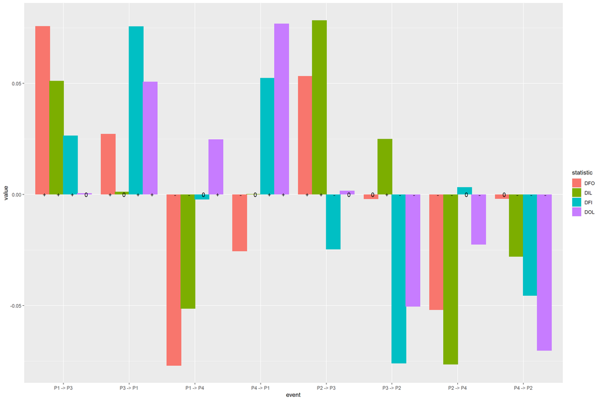

```r
events <- c("P1 -> P3", "P3 -> P1", "P1 -> P4", "P4 -> P1", "P2 -> P3", "P3 -> P2", "P2 -> P4", "P4 -> P2")
FOIL1 <- symmetric[symmetric$statistic %in% c("DFO", "DIL", "DFI", "DOL"), ]
FOIL1 <- FOIL1[FOIL1$event %in% events, ]
FOIL1$statistic <- factor(FOIL1$statistic, levels <- c("DFO", "DIL", "DFI", "DOL"))
FOIL1$event <- factor(FOIL1$event, levels <- events)
ggplot(FOIL1, aes(fill = statistic, y = value, x = event)) +
    geom_bar(position = position_dodge(0.85), stat = "identity") +
  geom_text(position = position_dodge(0.85), aes(y = 0, label = sign, hjust = 0))
```

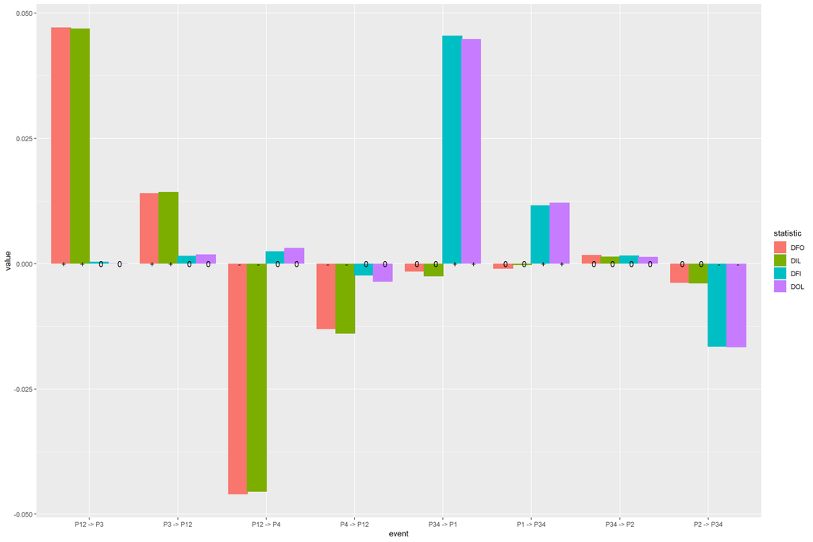

```r
events <- c("P12 -> P3", "P3 -> P12", "P12 -> P4", "P4 -> P12", "P34 -> P1", "P1 -> P34", "P34 -> P2", "P2 -> P34")
FOIL2 <- symmetric[symmetric$statistic %in% c("DFO", "DIL", "DFI", "DOL"), ]
FOIL2 <- FOIL2[FOIL2$event %in% events, ]
FOIL2$statistic <- factor(FOIL2$statistic, levels <- c("DFO", "DIL", "DFI", "DOL"))
FOIL2$event <- factor(FOIL2$event, levels <- events)
ggplot(FOIL2, aes(fill = statistic, y = value, x = event)) +
    geom_bar(position = position_dodge(0.85), stat = "identity") +
  geom_text(position = position_dodge(0.85), aes(y = 0, label = sign, hjust = 0))
```

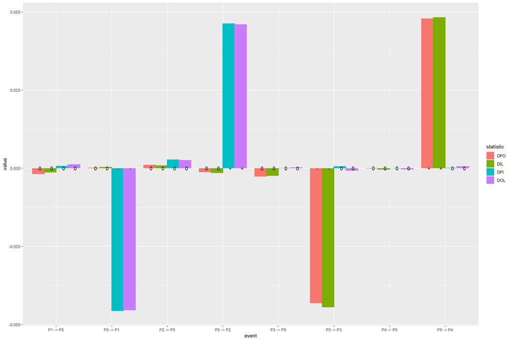

```r
events <- c("P1 -> P5", "P5 -> P1", "P2 -> P5", "P5 -> P2", "P3 -> P5", "P5 -> P3", "P4 -> P5", "P5 -> P4")
FOIL3 <- symmetric[symmetric$statistic %in% c("DFO", "DIL", "DFI", "DOL"), ]
FOIL3 <- FOIL3[FOIL3$event %in% events, ]
FOIL3$statistic <- factor(FOIL3$statistic, levels <- c("DFO", "DIL", "DFI", "DOL"))
FOIL3$event <- factor(FOIL3$event, levels <- events)
ggplot(FOIL3, aes(fill = statistic, y = value, x = event)) +
    geom_bar(position = position_dodge(0.85), stat = "identity") +
  geom_text(position = position_dodge(0.85), aes(y = 0, label = sign, hjust = 0))
```

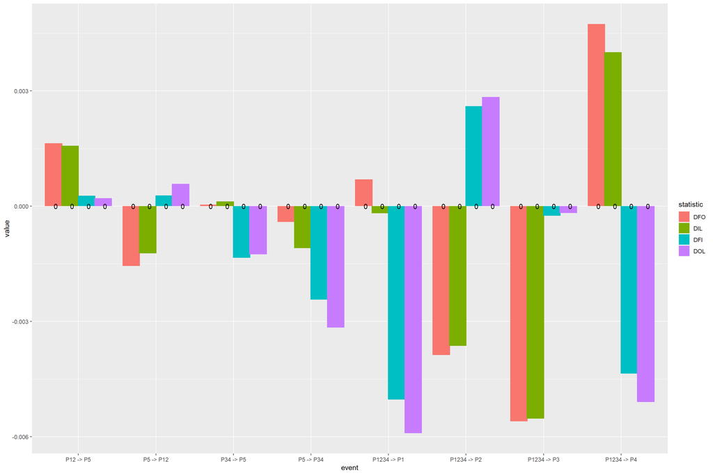

```r
events <- c("P12 -> P5", "P5 -> P12", "P34 -> P5", "P5 -> P34", "P1234 -> P1", "P1234 -> P2", "P1234 -> P3", "P1234 -> P4")
FOIL4 <- symmetric[symmetric$statistic %in% c("DFO", "DIL", "DFI", "DOL"), ]
FOIL4 <- FOIL4[FOIL4$event %in% events, ]
FOIL4$statistic <- factor(FOIL4$statistic, levels <- c("DFO", "DIL", "DFI", "DOL"))
FOIL4$event <- factor(FOIL4$event, levels <- events)
ggplot(FOIL4, aes(fill = statistic, y = value, x = event)) +
    geom_bar(position = position_dodge(0.85), stat = "identity") +
  geom_text(position = position_dodge(0.85), aes(y = 0, label = sign, hjust = 0))
```

These statistics are dominated by the singletons, and I don’t think the predictions hold with specifically (malignously) designed graphs. Going to study what happens to `DFO()` and others with such a graph and a very big sample, later.

```r
load("symmetric.RData")
print(tables[[1]])
```

```
## abbababa
##  AAAAB  AAABA  AAABB  AABAA  AABAB  AABBA  AABBB  ABAAA  ABAAB  ABABA  ABABB
## 262205 132378   1571 121464   1027  59010   4447 125180   1084   1467    212
##  ABBAA  ABBAB  ABBBA  ABBBB  BAAAA  BAAAB  BAABA  BAABB  BABAA  BABAB  BABBA
##   2122    203   4745    970 121913   1008   1223    183   5326    246   4987
##  BABBB  BBAAA  BBAAB  BBABA  BBABB  BBBAA  BBBAB  BBBBA
##   1072  59701   4278   4765    972  10852   1562  63827
```

The new categories don’t all have the zero signal; in particular gene flow from the outgroup can be mixed up with an ancient gene flow event.

LOOKS LIKE “P34 -> P2” AND EVERYTHING INVOLVING “P1234” ARE ACTING STRANGE, IGNORE FOR NOW!

## An attempt to adapt DFOIL method to ancient samples

One of the issues we had with the new polar bear paper was the use of ancient sample despite the fact that DFOIL utilises private alleles. In chat proposed just dropping the private allele terms from the definition of the statistics, that is, using the functions `dfo()`, `dil()`, `dfi()`, `dol()` instead. Here I demonstrate that this will not work.

We could consider just using the new signs, but only if there’s a reason they are stable within admixture categories, that they do not change if we make another admixture graph with different admixture proportions and branch lengths.

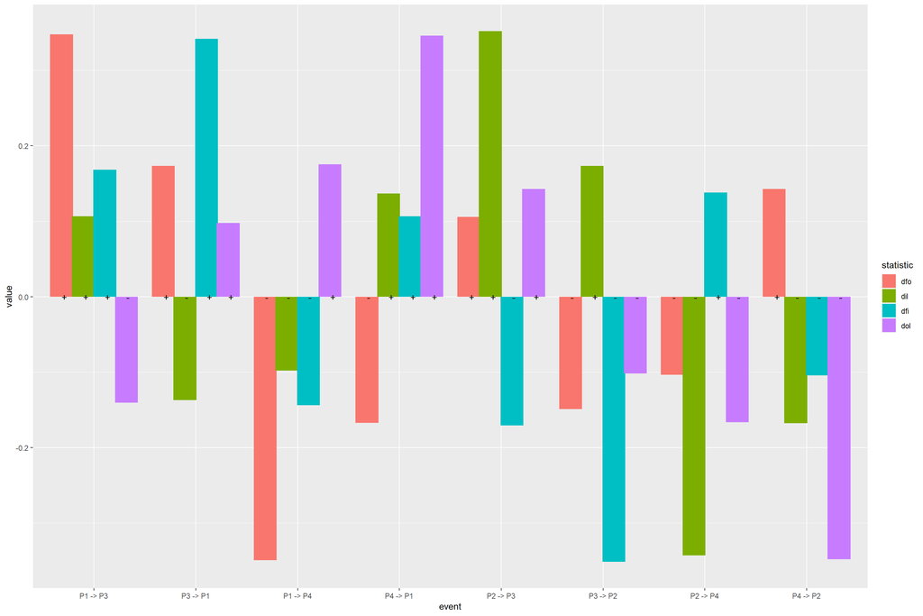

```r
events <- c("P1 -> P3", "P3 -> P1", "P1 -> P4", "P4 -> P1", "P2 -> P3", "P3 -> P2", "P2 -> P4", "P4 -> P2")
foil1 <- symmetric[symmetric$statistic %in% c("dfo", "dil", "dfi", "dol"), ]
foil1 <- foil1[foil1$event %in% events, ]
foil1$statistic <- factor(foil1$statistic, levels <- c("dfo", "dil", "dfi", "dol"))
foil1$event <- factor(foil1$event, levels <- events)
ggplot(foil1, aes(fill = statistic, y = value, x = event)) +
    geom_bar(position = position_dodge(0.85), stat = "identity") +
  geom_text(position = position_dodge(0.85), aes(y = 0, label = sign, hjust = 0))
```

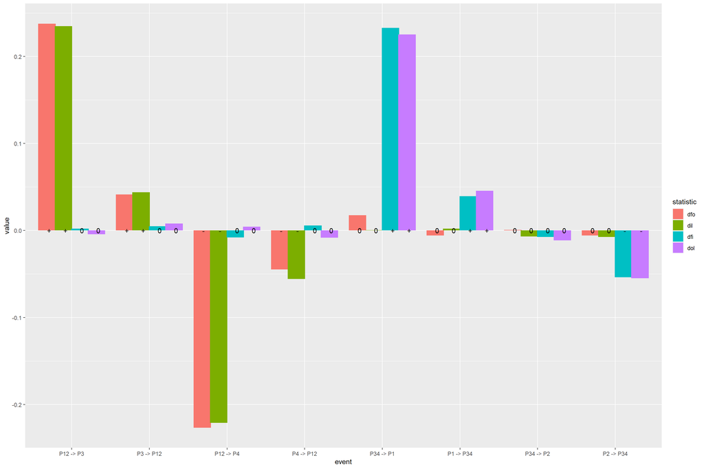

```r
events <- c("P12 -> P3", "P3 -> P12", "P12 -> P4", "P4 -> P12", "P34 -> P1", "P1 -> P34", "P34 -> P2", "P2 -> P34")
foil2 <- symmetric[symmetric$statistic %in% c("dfo", "dil", "dfi", "dol"), ]
foil2 <- foil2[foil2$event %in% events, ]
foil2$statistic <- factor(foil2$statistic, levels <- c("dfo", "dil", "dfi", "dol"))
foil2$event <- factor(foil2$event, levels <- events)
ggplot(foil2, aes(fill = statistic, y = value, x = event)) +
    geom_bar(position = position_dodge(0.85), stat = "identity") +
  geom_text(position = position_dodge(0.85), aes(y = 0, label = sign, hjust = 0))
```

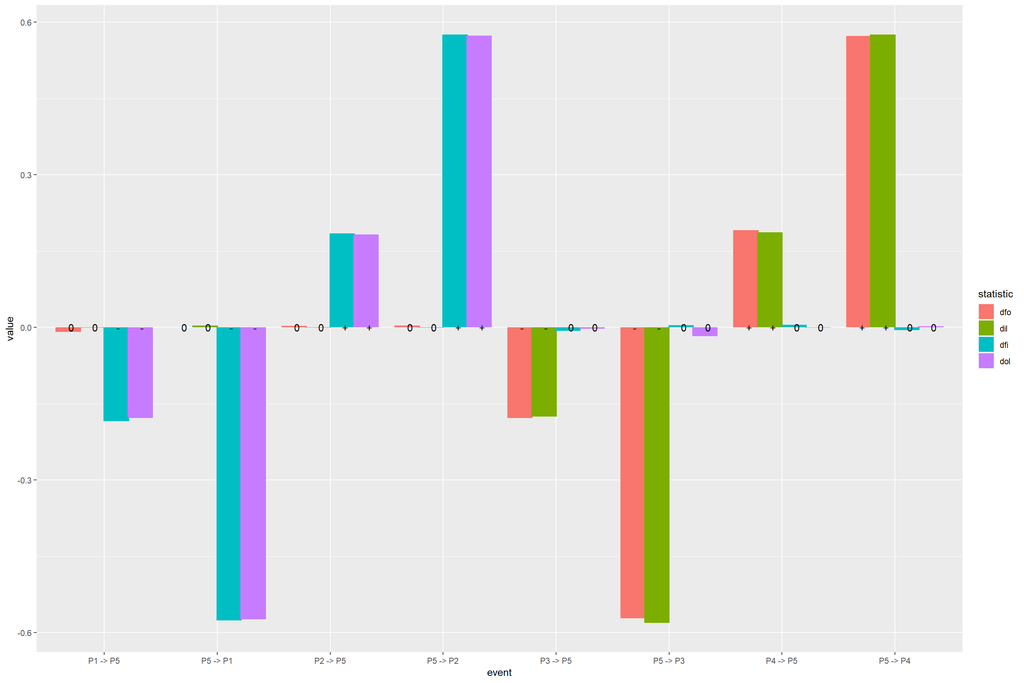

```r
events <- c("P1 -> P5", "P5 -> P1", "P2 -> P5", "P5 -> P2", "P3 -> P5", "P5 -> P3", "P4 -> P5", "P5 -> P4")
foil3 <- symmetric[symmetric$statistic %in% c("dfo", "dil", "dfi", "dol"), ]
foil3 <- foil3[foil3$event %in% events, ]
foil3$statistic <- factor(foil3$statistic, levels <- c("dfo", "dil", "dfi", "dol"))
foil3$event <- factor(foil3$event, levels <- events)
ggplot(foil3, aes(fill = statistic, y = value, x = event)) +
    geom_bar(position = position_dodge(0.85), stat = "identity") +
  geom_text(position = position_dodge(0.85), aes(y = 0, label = sign, hjust = 0))
```

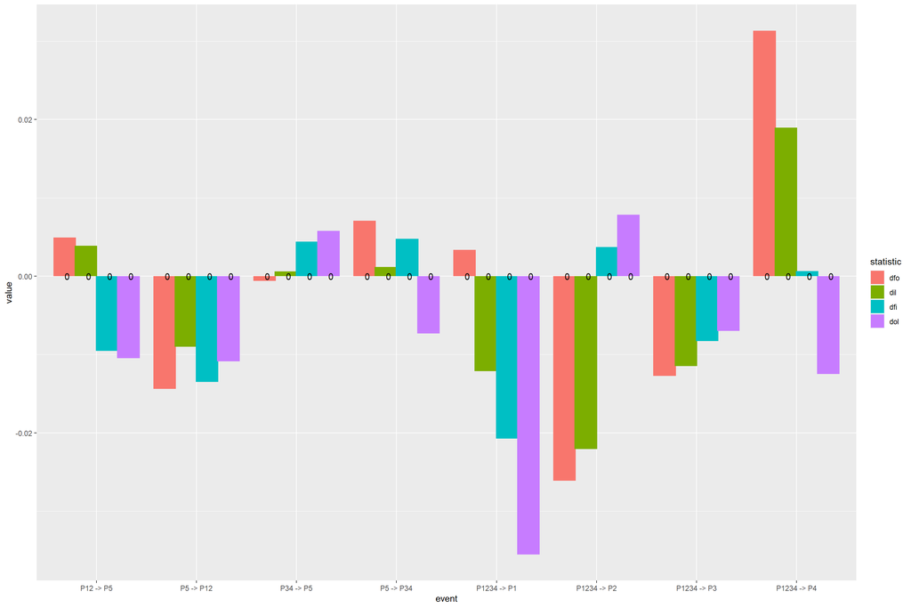

```r
events <- c("P12 -> P5", "P5 -> P12", "P34 -> P5", "P5 -> P34", "P1234 -> P1", "P1234 -> P2", "P1234 -> P3", "P1234 -> P4")
foil4 <- symmetric[symmetric$statistic %in% c("dfo", "dil", "dfi", "dol"), ]
foil4 <- foil4[foil4$event %in% events, ]
foil4$statistic <- factor(foil4$statistic, levels <- c("dfo", "dil", "dfi", "dol"))
foil4$event <- factor(foil4$event, levels <- events)
ggplot(foil4, aes(fill = statistic, y = value, x = event)) +
    geom_bar(position = position_dodge(0.85), stat = "identity") +
  geom_text(position = position_dodge(0.85), aes(y = 0, label = sign, hjust = 0))
```

These are whatever, let’s not care about them any further.

## The plots for difference statistics

Finally, let’s see if my difference statistics follow the predictions made in the Overleaf document. Still ignore “P34 -> P2” and “P1234”.

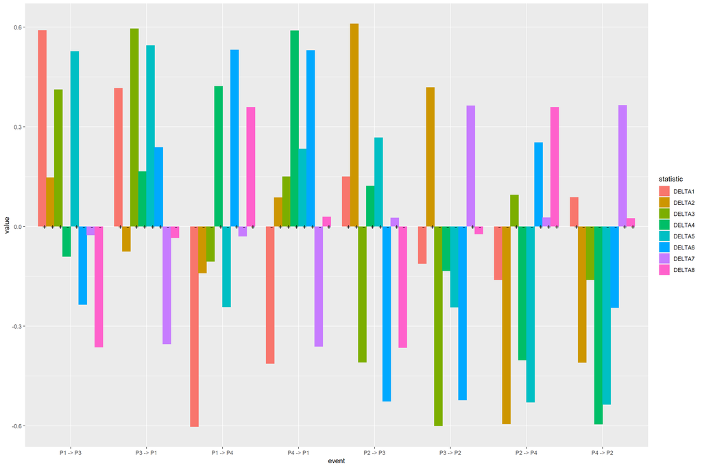

```r
events <- c("P1 -> P3", "P3 -> P1", "P1 -> P4", "P4 -> P1", "P2 -> P3", "P3 -> P2", "P2 -> P4", "P4 -> P2")
delta1 <- symmetric[symmetric$statistic %in% c("DELTA1", "DELTA2", "DELTA3", "DELTA4", "DELTA5", "DELTA6", "DELTA7", "DELTA8"), ]
delta1 <- delta1[delta1$event %in% events, ]
delta1$statistic <- factor(delta1$statistic, levels <- c("DELTA1", "DELTA2", "DELTA3", "DELTA4", "DELTA5", "DELTA6", "DELTA7", "DELTA8"))
delta1$event <- factor(delta1$event, levels <- events)
ggplot(delta1, aes(fill = statistic, y = value, x = event)) +
    geom_bar(position = position_dodge(0.85), stat = "identity") +
  geom_text(position = position_dodge(0.85), aes(y = 0, label = sign, hjust = 0))
```

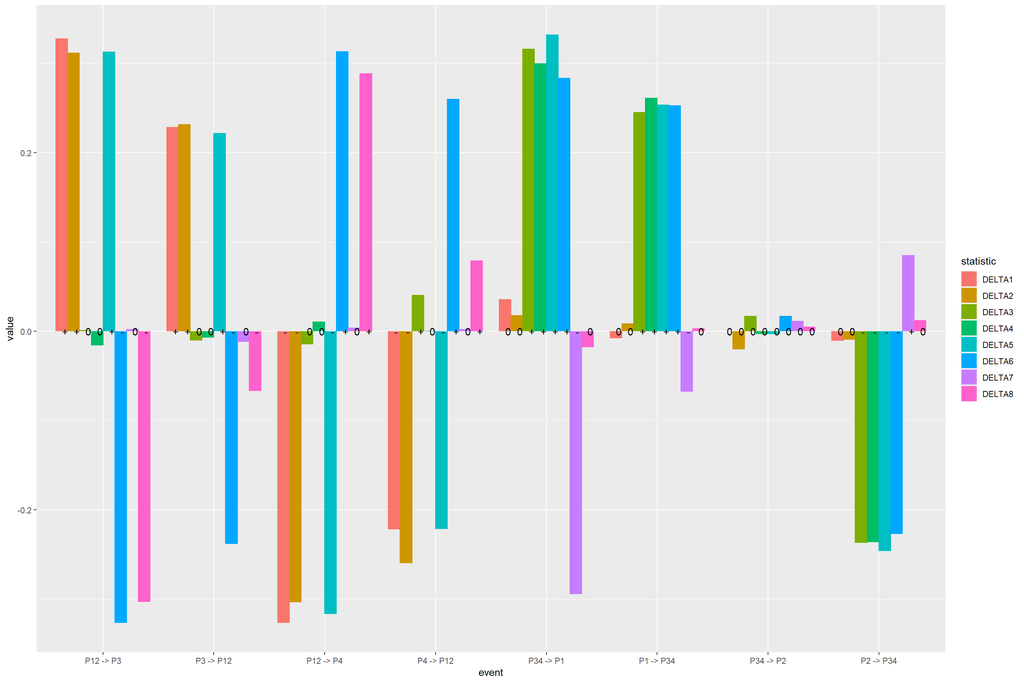

```r
events <- c("P12 -> P3", "P3 -> P12", "P12 -> P4", "P4 -> P12", "P34 -> P1", "P1 -> P34", "P34 -> P2", "P2 -> P34")
delta2 <- symmetric[symmetric$statistic %in% c("DELTA1", "DELTA2", "DELTA3", "DELTA4", "DELTA5", "DELTA6", "DELTA7", "DELTA8"), ]
delta2 <- delta2[delta2$event %in% events, ]
delta2$statistic <- factor(delta2$statistic, levels <- c("DELTA1", "DELTA2", "DELTA3", "DELTA4", "DELTA5", "DELTA6", "DELTA7", "DELTA8"))
delta2$event <- factor(delta2$event, levels <- events)
ggplot(delta2, aes(fill = statistic, y = value, x = event)) +
    geom_bar(position = position_dodge(0.85), stat = "identity") +
  geom_text(position = position_dodge(0.85), aes(y = 0, label = sign, hjust = 0))
```

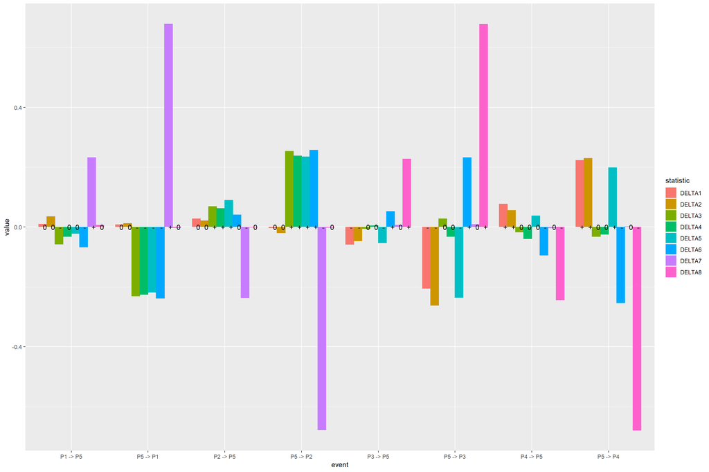

```r
events <- c("P1 -> P5", "P5 -> P1", "P2 -> P5", "P5 -> P2", "P3 -> P5", "P5 -> P3", "P4 -> P5", "P5 -> P4")
delta3 <- symmetric[symmetric$statistic %in% c("DELTA1", "DELTA2", "DELTA3", "DELTA4", "DELTA5", "DELTA6", "DELTA7", "DELTA8"), ]
delta3 <- delta3[delta3$event %in% events, ]
delta3$statistic <- factor(delta3$statistic, levels <- c("DELTA1", "DELTA2", "DELTA3", "DELTA4", "DELTA5", "DELTA6", "DELTA7", "DELTA8"))
delta3$event <- factor(delta3$event, levels <- events)
ggplot(delta3, aes(fill = statistic, y = value, x = event)) +
    geom_bar(position = position_dodge(0.85), stat = "identity") +
  geom_text(position = position_dodge(0.85), aes(y = 0, label = sign, hjust = 0))
```

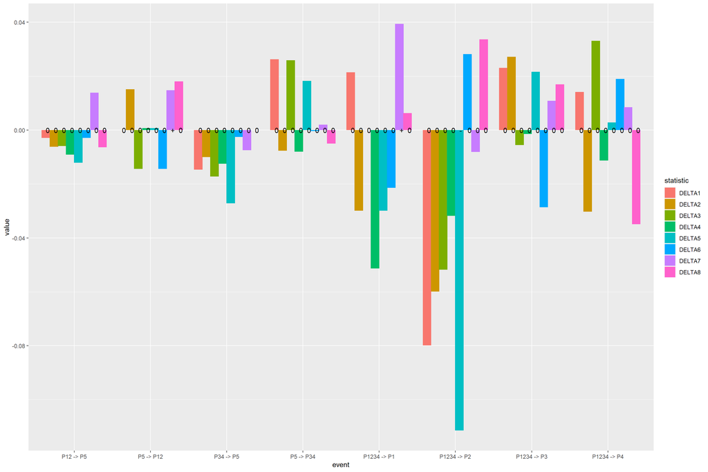

```r
events <- c("P12 -> P5", "P5 -> P12", "P34 -> P5", "P5 -> P34", "P1234 -> P1", "P1234 -> P2", "P1234 -> P3", "P1234 -> P4")
delta4 <- symmetric[symmetric$statistic %in% c("DELTA1", "DELTA2", "DELTA3", "DELTA4", "DELTA5", "DELTA6", "DELTA7", "DELTA8"), ]
delta4 <- delta4[delta4$event %in% events, ]
delta4$statistic <- factor(delta4$statistic, levels <- c("DELTA1", "DELTA2", "DELTA3", "DELTA4", "DELTA5", "DELTA6", "DELTA7", "DELTA8"))
delta4$event <- factor(delta4$event, levels <- events)
ggplot(delta4, aes(fill = statistic, y = value, x = event)) +
    geom_bar(position = position_dodge(0.85), stat = "identity") +
  geom_text(position = position_dodge(0.85), aes(y = 0, label = sign, hjust = 0))
```

We see that things pretty much work. There’s some instances of misclassifying a zero (like Delta3 of “P4 -> P12”). More strict alpha (currently 0.01) could help. It would make some plusses and minuses into zero, but that’s probably OK as I’m thinking right now that the best solution to low power is to predict some of the statistics in some admixture scenarios as EITHER plus or a zero (or as either minus or a zero). There’s also some theoretical justification for this. So I’m in scratching the idea of power analysis, some of the statistics just require insane amounts of power to detect them (even million independent polymorphisms are not enough). (I guess there’s no reason to restrict to a single individual so there’s insane amounts of power available all right, but not for fossils…)

Hudson, Richard R. 2002. “Generating Samples Under a Wright–Fisher Neutral Model of Genetic Variation.” *Bioinformatics* 18 (2): 337–38.

Pease, James B, and Matthew W Hahn. 2015. “Detection and Polarization of Introgression in a Five-Taxon Phylogeny.” *Systematic Biology* 64 (4): 651–62.